# Comparison plots of samples and gene/regions

Report created by [RAPID](https://rapid-doc.readthedocs.io/en/latest/Description.html)

08 February 2019

This report provides comparison plots of various samples and gene/region in normal and log2 scale.

###### Note: If graphs under some category are absent, it means there is not sufficient data with respect to that category.

### Quality Plots Sample Comparison Gene/Region Comparison

### Clustered heatmap of TPM

[See Help](https://rapid-doc.readthedocs.io/en/latest/UseCases.html#clustered-heatmap-of-tpm) Back To Top

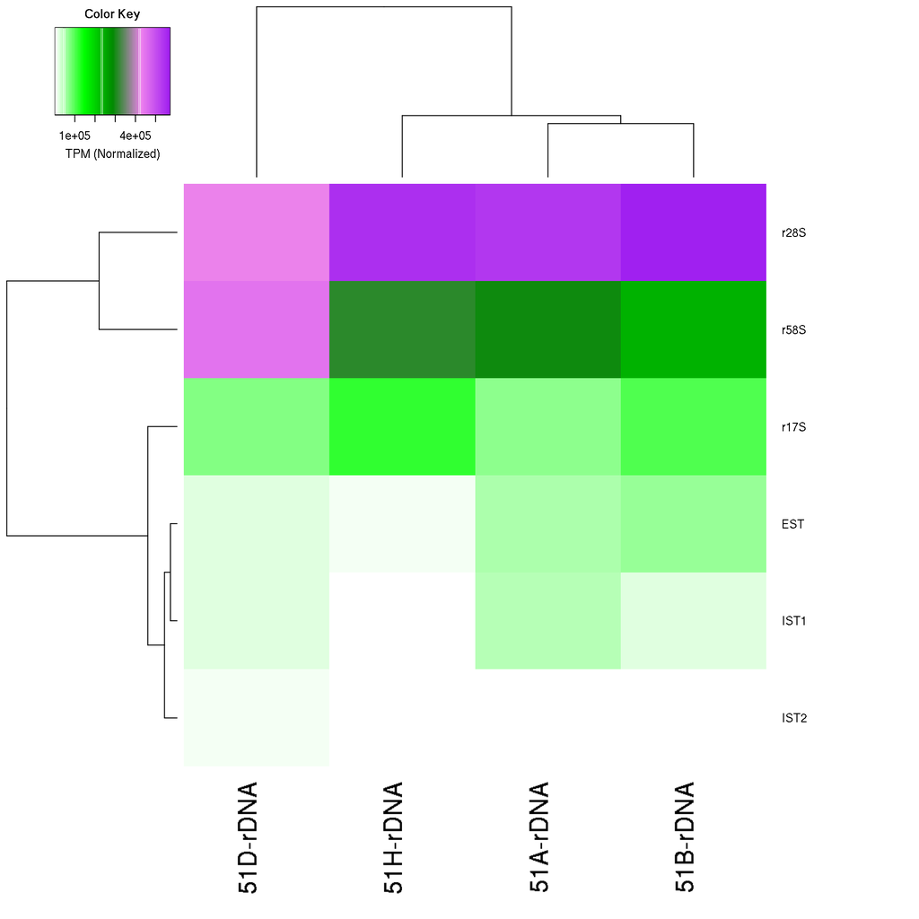

### Clustered heatmap of antisense ratio

[See Help](https://rapid-doc.readthedocs.io/en/latest/UseCases.html#clustered-heatmap-of-antisense-ratio) Back To Top

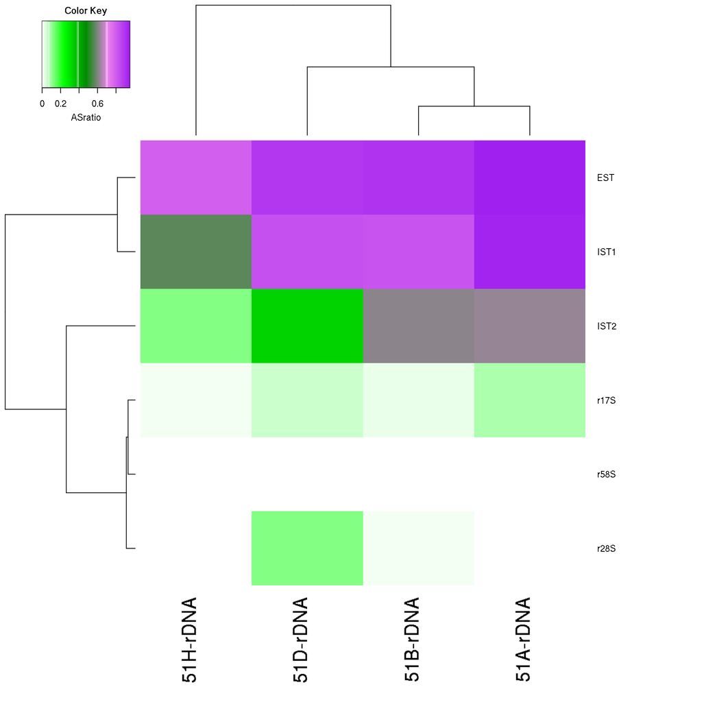

### Clustered heatmap of average read count (log2 scale)

[See Help](https://rapid-doc.readthedocs.io/en/latest/UseCases.html#clustered-heatmap-of-average-read-count-log2-scale) Back To Top

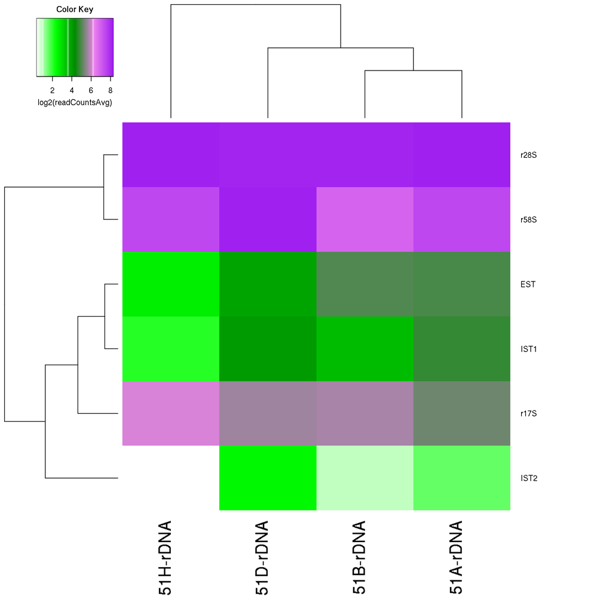

### PCA plot of samples

[See Help](https://rapid-doc.readthedocs.io/en/latest/UseCases.html#pca-plot-of-samples) Back To Top

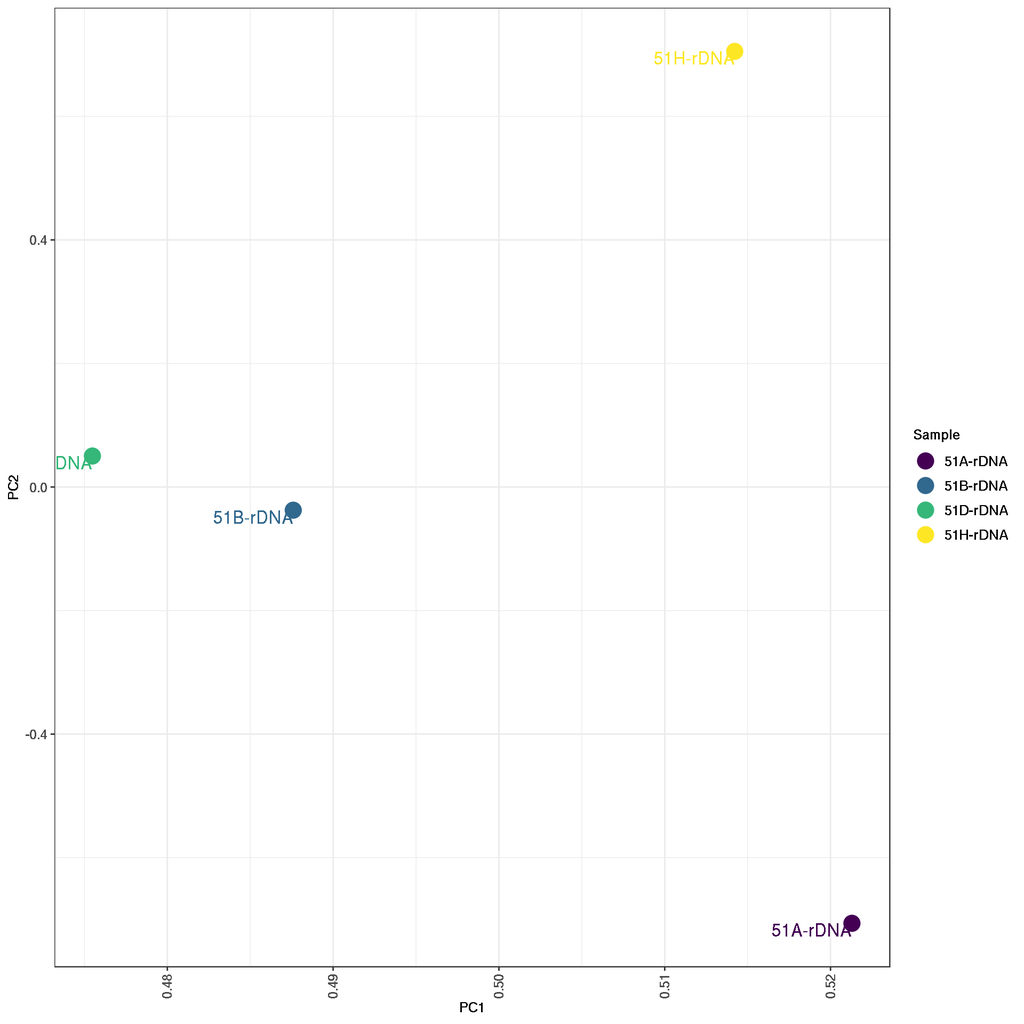

### MDS plot of samples

[See Help](https://rapid-doc.readthedocs.io/en/latest/UseCases.html#mds-plot-of-samples) Back To Top

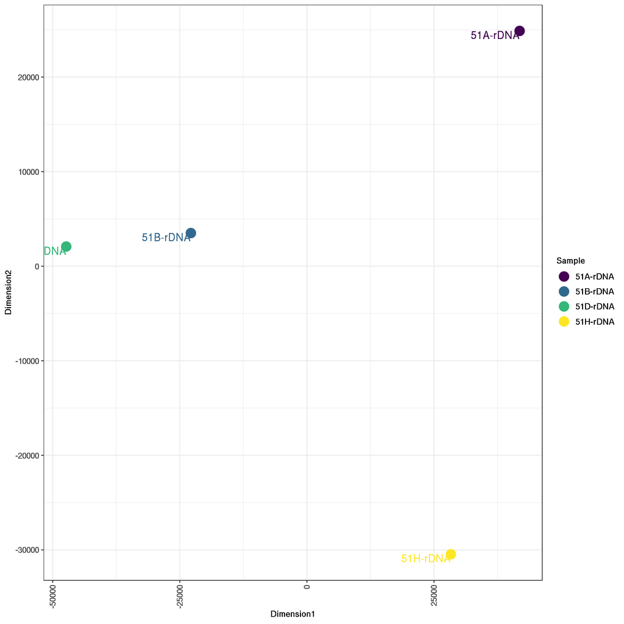

### Box plot of regions

[See Help](https://rapid-doc.readthedocs.io/en/latest/UseCases.html#box-plot-of-read-counts) Back To Top

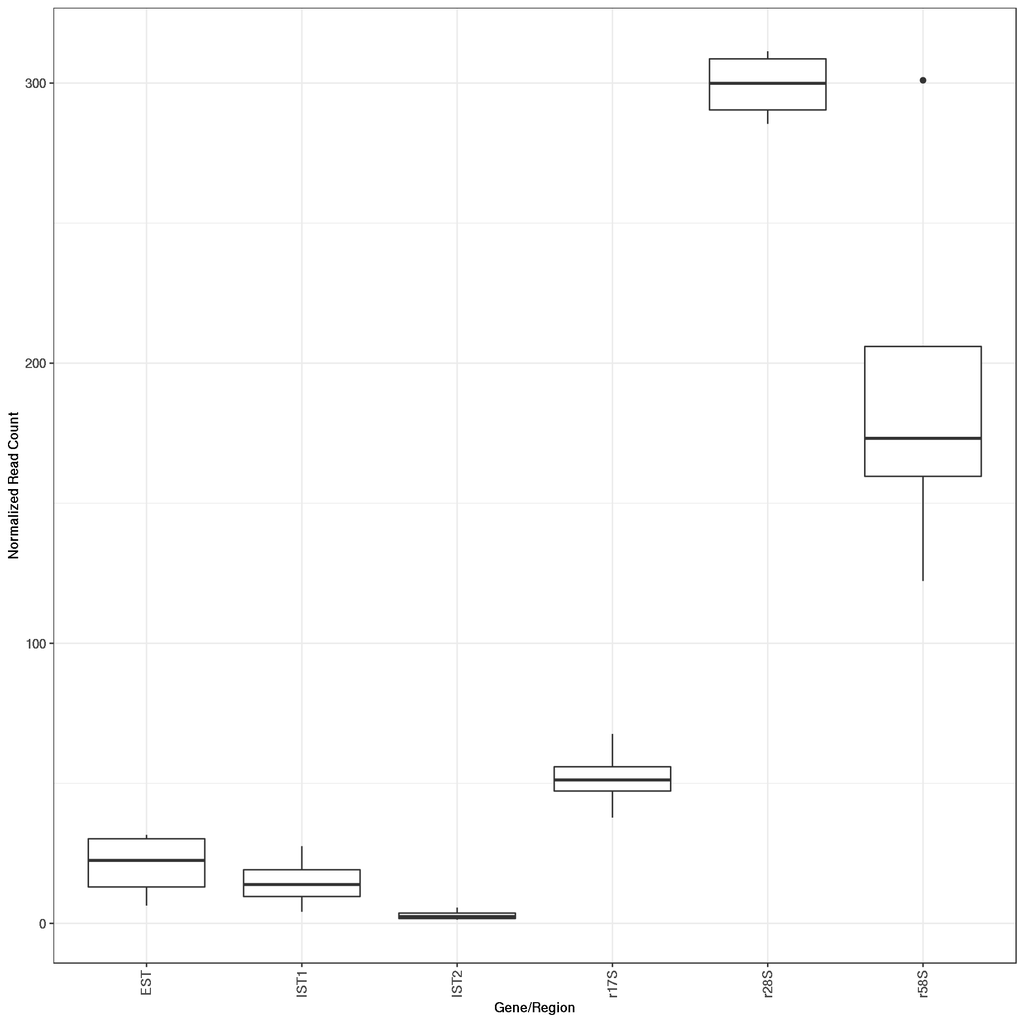

### Sample wise comparison of read counts for each gene/region

[See Help](https://rapid-doc.readthedocs.io/en/latest/UseCases.html#sample-wise-comparison-of-read-counts-for-each-gene-region) Back To Top

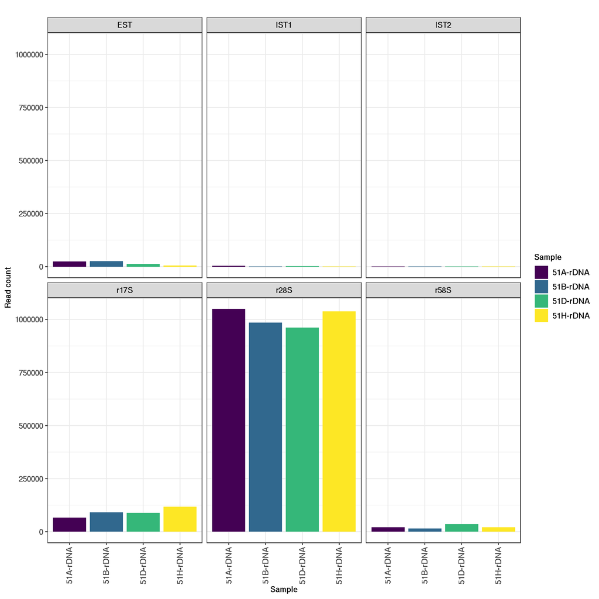

### Sample wise comparison of read counts for each gene/region (log2 scale)

[See Help](https://rapid-doc.readthedocs.io/en/latest/UseCases.html#sample-wise-comparison-of-read-counts-for-each-gene-region-log2-scale) Back To Top

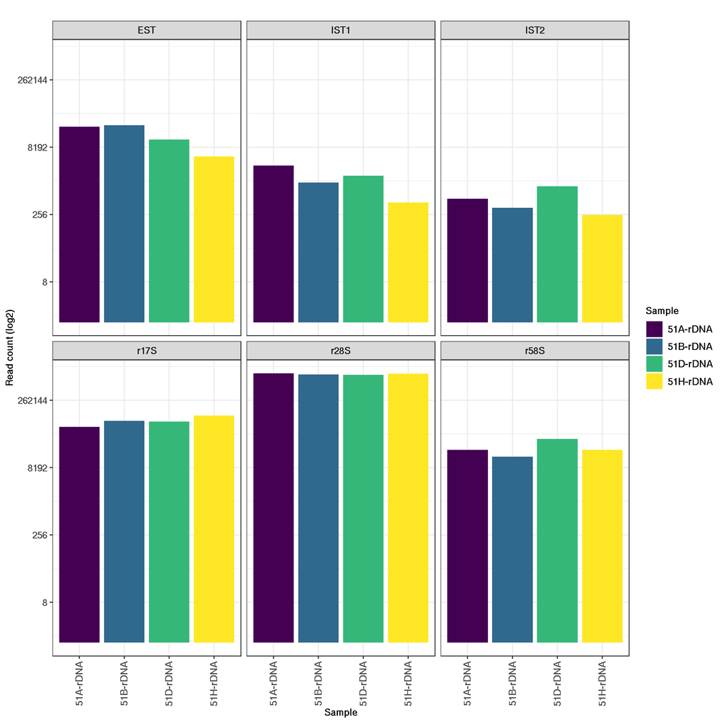

### Sample wise comparison of TPM for each gene/region

[See Help](https://rapid-doc.readthedocs.io/en/latest/UseCases.html#sample-wise-comparison-of-tpm-for-each-gene-region) Back To Top

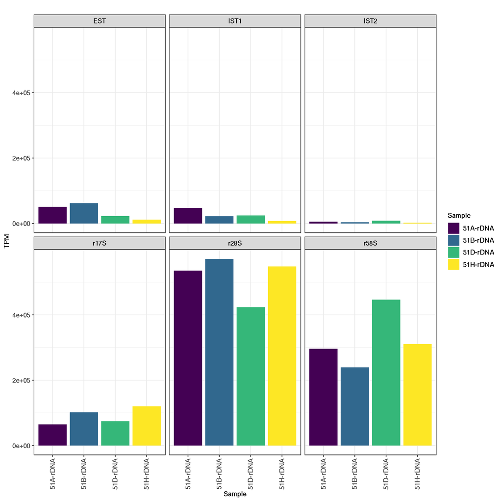

### Sample wise comparison of TPM for each gene/region (log2 scale)

[See Help](https://rapid-doc.readthedocs.io/en/latest/UseCases.html#sample-wise-comparison-of-tpm-for-each-gene-region-log2-scale) Back To Top

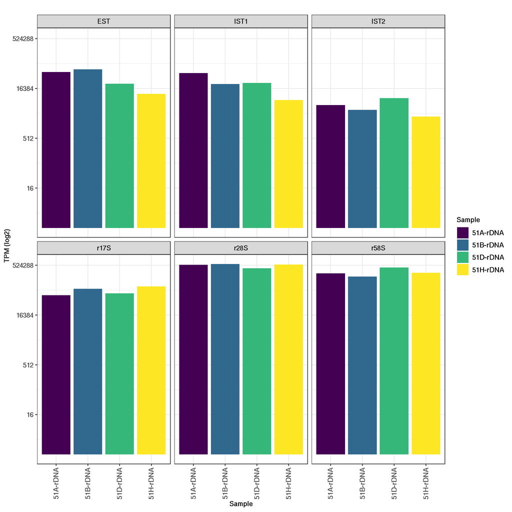

### Sample wise comparison of antisense ratio for each gene/region

[See Help](https://rapid-doc.readthedocs.io/en/latest/UseCases.html#sample-wise-comparison-of-antisense-ratio-for-each-gene-region) Back To Top

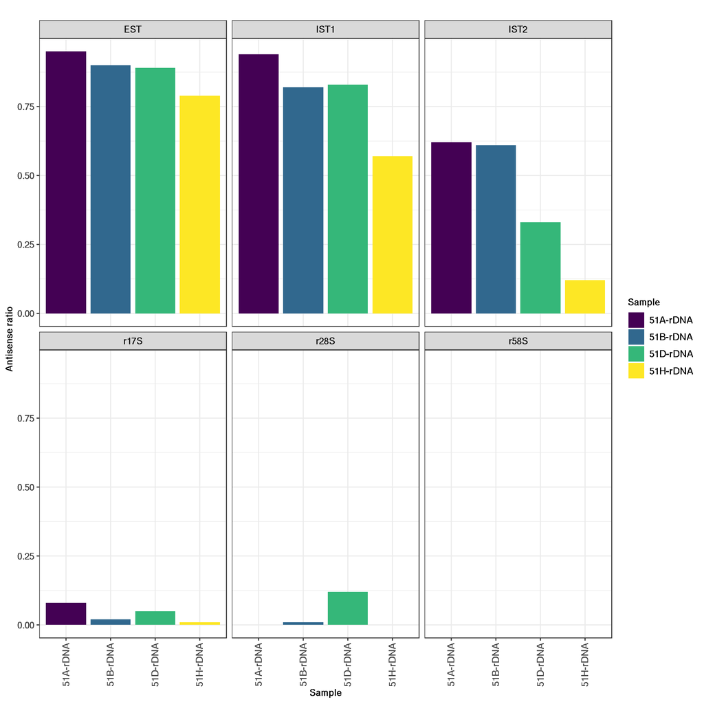

### Gene/Region wise comparsion of read counts for each sample

[See Help](https://rapid-doc.readthedocs.io/en/latest/UseCases.html#gene-region-wise-comparsion-of-average-read-counts-for-each-sample) Back To Top

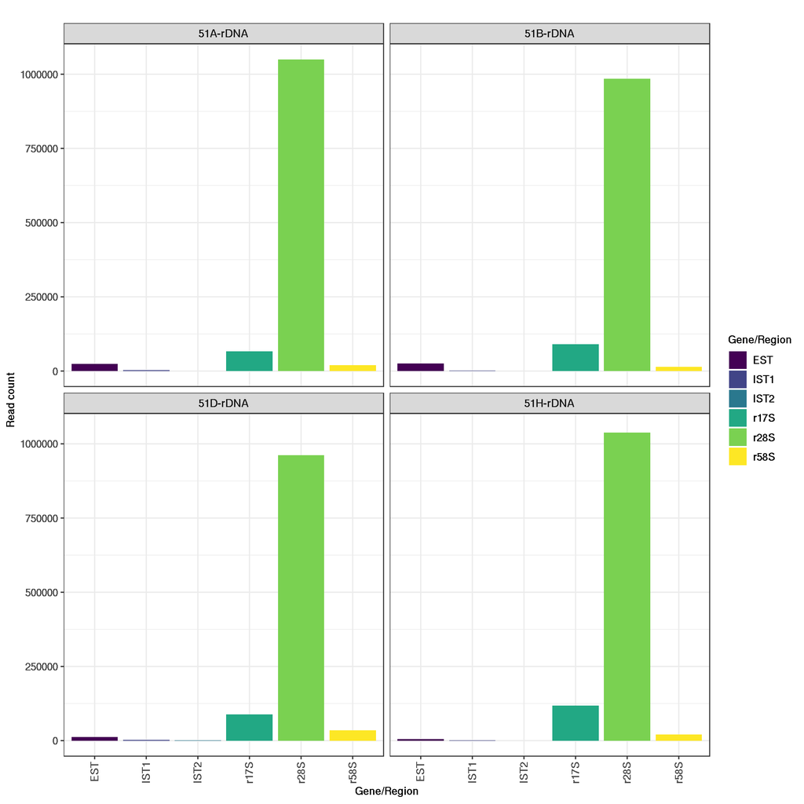

### Gene/Region wise comparsion of read counts for each sample (log2 scale)

[See Help](https://rapid-doc.readthedocs.io/en/latest/UseCases.html#gene-region-wise-comparsion-of-average-read-counts-for-each-sample-log2-scale) Back To Top

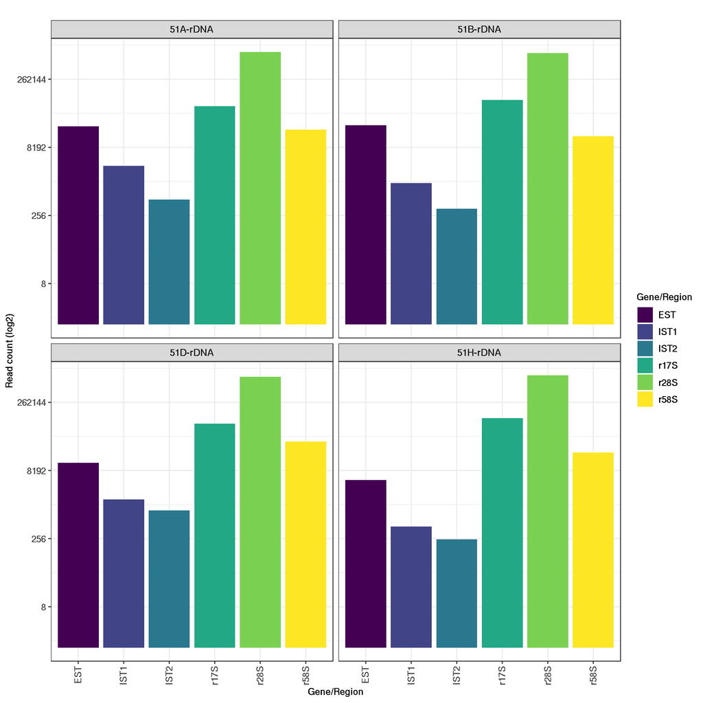

### Gene/Region wise comparsion of TPM for each sample

[See Help](https://rapid-doc.readthedocs.io/en/latest/UseCases.html#gene-region-wise-comparsion-of-tpm-for-each-sample) Back To Top

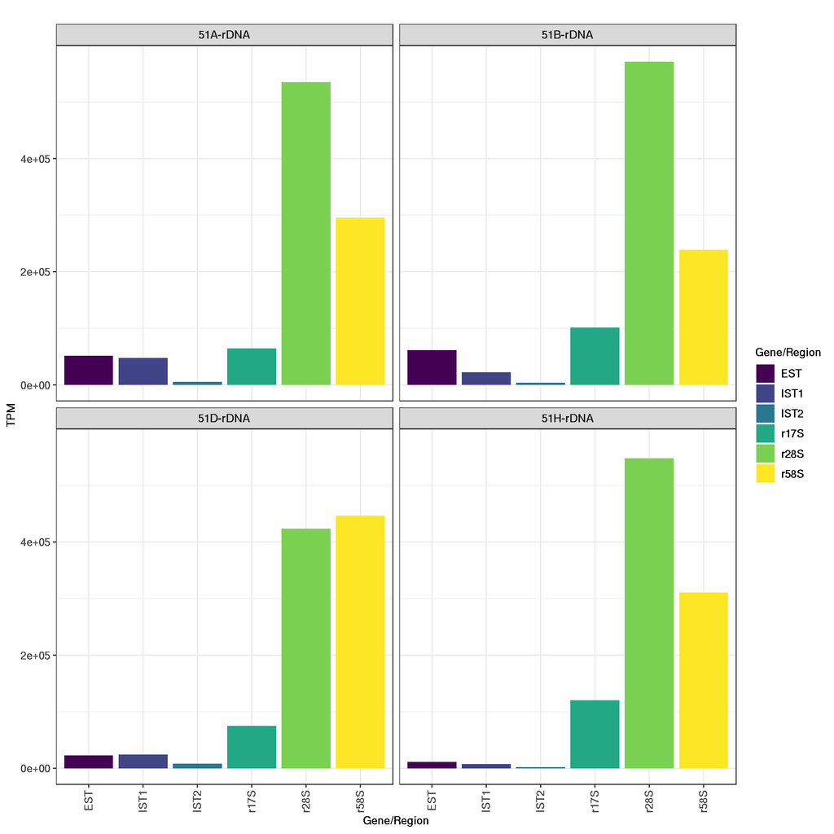

### Gene/Region wise comparsion of TPM for each sample (log2 scale)

[See Help](https://rapid-doc.readthedocs.io/en/latest/UseCases.html#gene-region-wise-comparsion-of-tpm-for-each-sample-log2-scale) Back To Top

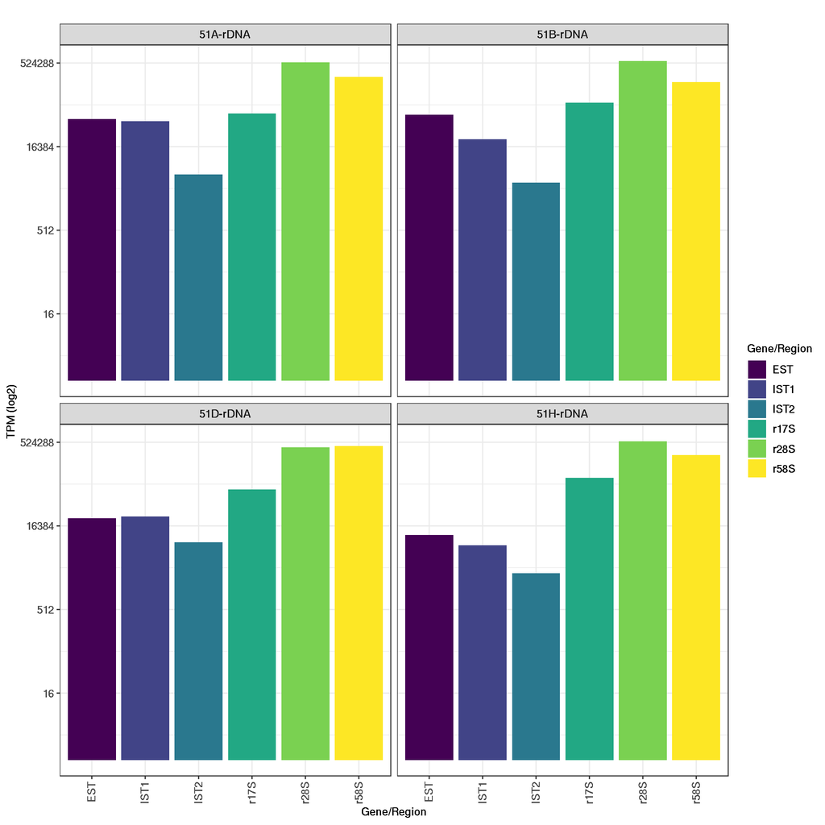

### Gene/Region wise comparison of antisense ratio for each sample

[See Help](https://rapid-doc.readthedocs.io/en/latest/UseCases.html#gene-region-wise-comparison-of-antisense-ratio-for-each-sample) Back To Top

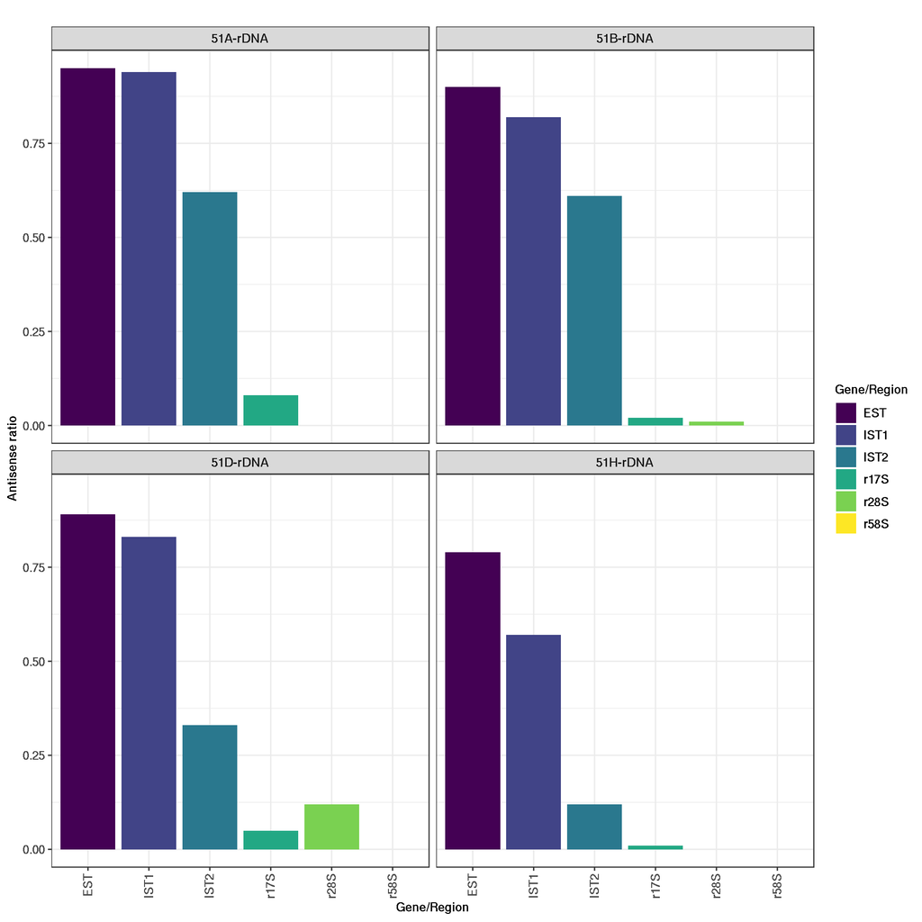

This document was created with R Markdown and the Knit package. Markdown is a simple formatting syntax for authoring HTML, PDF, and MS Word documents. For more details on using R Markdown see http://rmarkdown.rstudio.com.